# date_dead_dendro

Carmen

May 22, 2019

Process:

1. Compare individual ABCO series to the summarized series from live ABCO
2. Make lists of trees that look like they pretty clearly died in 2017, 2016, 2015, or unknown
3. Plot summarized series for the subset of trees I think I can date and compare it to the live ABCO chronology
4. Summarize physical characteristics from the trees by estimated age of death
5. Try to use those physical characteristics to age the remainder of the trees by creating a “year of death rubric”

# Read in data

### compiled dendro files

```r
setwd("~/Shrubs-Seedlings/code/GrowthMortality_Analysis/")
load(file = "../../data/GrowthMortality/dead_pipo_rwl.Rdata")
rwlp <- rwl_dead_pipo
load(file = "../../data/GrowthMortality/dead_abco_rwl.Rdata")
rwla <- rwl_dead_abco
```

### live detrended data

```r
load("../../compiled_data/live_chron_abco.Rdata")
dfa_live <- dfa
remove(dfa)
load("../../compiled_data/live_chron_pipo.Rdata")
dfp_live <- dfp
remove(dfp)
```

### detailed dead seedling characteristic data to use for creating a year of death rubric

```r
load("../../compiled_data/growth_mortality/dendro_all_vars.Rdata")
```

#### separate detailed data into abco and pipo

```r
dfafull <- join %>%
  filter(SPECIES == "ABCO")
dfpfull <- join %>%
  filter(SPECIES == "PIPO")
```

# Clean up Growing column

```r
dfafull_bu <- dfafull
```

## Standardize the response types

```r
dfafull <- dfafull_bu
dfafull <- dfafull %>%
  rename(Growing = `Growing?`) %>%
  mutate(Growing = toupper(Growing)) %>%
  mutate(Growing = ifelse(Growing == "GROWING", "YES", Growing)) %>%
  mutate(Growing = ifelse(Growing == "NOT GROWING", "NO", Growing)) %>%
  mutate(Growing = ifelse(Growing == "EARLY 2017 GROWTH", "YES", Growing)) %>%
  mutate(Growing = ifelse(Growing == "BEFORE 2017 GROWTH", "NO", Growing))

unique(dfafull$Growing)
```

```
## [1] "NO"                "NA"                "YES"
## [4] "UNKNOWN"           "AFTER 2017 GROWTH"
```

## Correct tree that says it’s not growing but really looks like it’s growing from the photo

```r
dfafull <- dfafull %>%
  mutate(Growing = ifelse(tree == 139, "YES", Growing))
```

# Create functions

### Make a function to plot the trend for each tree

```r
ringplot <- function(i){
  ggplot(data = dfa %>% filter(tree == i) %>% filter(Year >2008))+
  geom_line(aes(x = Year, y = growth_detrended))+
  geom_point(aes(x = Year, y = growth_detrended))+
  ggtitle(paste(i))+
  scale_x_continuous(breaks = seq(min(dfa$Year), max(dfa$Year), by = 1))+
  theme_bw()+
  theme(panel.grid.minor = element_blank())
}
```

### Make vectors to add to

“died2017” means that the dead tree’s “2016” year matches live trees’ “2016” - AKA the tree put on a partial ring in 2017 and then died

```r
died2017 <- c()
died2016 <- c()
died2015 <- c()
unkn <- c()
```

### Make functions to add and subtract trees from the vectors

```r
add2017 <- function(new){
  died2017 <<- c(died2017, new)
}
```

```r
add2016 <- function(new){
  died2016 <<- c(died2016, new)
}
```

```r
add2015 <- function(new){
  died2015 <<- c(died2015, new)
}
```

```r
addunkn <- function(new){
  unkn <<- c(unkn, new)
  if(new %in% died2017){
    died2017<<- died2017[died2017 != new]
  }
}
```

```r
subtract2016 <- function(new){
  if(new %in% died2016){
    died2016<<- died2016[died2016 != new]
  }
}
```

### Make a function to add to a vector of trees whose age assignment I feel confident about BASED SOLELY ON RING WIDTHS

```r
sure <- c()
addsure <- function(new){
  sure <<- c(sure, new)
}
```

### Make a function to look at all the physical traits of a seedling

```r
look <- function(treenum){
  print(dfafull %>%
    dplyr::select(tree, HEIGHT, PERC_NEEDLES, NEEDLE_COLOR, BARK, BUDS, Growing)  %>%
    filter(tree == treenum) %>%
    distinct())
}
```

# Assign green trees as 2017 death

## Find which trees have any mention of green

```r
summary(as.factor(dfafull$NEEDLE_COLOR))
```

```
##                             brown                              gray
##                                 3                                18
##                        gray brown                          gray/red
##                                 9                                 3
##                   green, tan, red                          greenish
##                                 3                                 3
##                              grey                       light green
##                                 9                                 6
##             light green to orange                light green to red
##                                 3                                 3
##         light green to red or tan                                na
##                                 3                               246
##                            orange                     orange to tan
##                                 3                                 3
##                               red                           red-tan
##                               135                                 3
##                red to light brown                red to light green
##                                 3                                 6
##                        red to tan                          red/gray
##                                 6                                 3
##                     reddish brown                       reddish tan
##                                 6                                 3
## reddish tan with some light green                               tan
##                                 3                                 6
##                tan to light green
##                                 3
```

```r
sort(unique(dfafull[grep("green", dfafull$NEEDLE_COLOR),]$tree))
```

```
##  [1] "100" "127" "16"  "169" "201" "208" "211" "30"  "32"  "52"  "55"
```

## Check for green in the photos

### Modify needle color column if I see green in the photo that wasn’t recorded

```r
dfafull <- dfafull %>%
  mutate(NEEDLE_COLOR = ifelse(tree == 215, "red to light green", NEEDLE_COLOR))
```

#### And remove it from the 2016 list

```r
subtract2016(215)
```

### Make a vector of trees whose photos had green

```r
definitely_green <- c(201, 100, 30, 127, 16, 211, 32, 52, 55, 169, 215, 208)
```

## If there’s actually green in the photos, add that seedling to the list of trees that died in 2017 if you haven’t already

```r
add2017(201)
add2017(55)
add2017(100)
add2017(30)
add2017(127)
add2017(16)
add2017(211)
add2017(32)
add2017(52)
add2017(169)
add2017(215)
add2017(208)
```

# Detrend using horizontal line method

## PIPO

```r
rwlp_dt <- detrend(rwl = rwlp, method = "Mean")
```

## ABCO

```r
rwla_dt <- detrend(rwl = rwla, method = "Mean")
```

# Reshape data frame to identify trees with the most rings

```r
rwla2 <- rwla %>%
  mutate(year = row.names(rwla))
rwla2 <- gather(rwla2, key = "tree", value = "growth", 1:ncol(rwla)) %>%
  filter(!is.na(growth))
rwla2_summary <- rwla2 %>%
  group_by(tree) %>%
  summarize(n = n()) %>%
  arrange(desc(n))
rwla2_summary
```

```
## # A tibble: 82 x 2
##    tree      n
##    <chr> <int>
##  1 201      10
##  2 41       10
##  3 129       9
##  4 161       9
##  5 51        9
##  6 68        9
##  7 78        9
##  8 102       8
##  9 131       8
## 10 139       8
## # ... with 72 more rows
```

# Reshape detrended means in order to look at each tree’s trend

### PIPO

```r
dfp <- as.data.frame(t(rwlp_dt))
dfp$tree <- row.names(dfp)
dfp <- gather(dfp, key = "Year", value = "growth_detrended", c(1:13))
dfp <- dfp %>%
  filter(!is.na(growth_detrended))
```

### ABCO

```r
dfa <- as.data.frame(t(rwla_dt))
dfa$tree <- row.names(dfa)
dfa <- gather(dfa, key = "Year", value = "growth_detrended", c(1:13))
dfa <- dfa %>%
  filter(!is.na(growth_detrended))
```

```r
dfa <- dfa %>%
  mutate(Year =as.numeric(Year))
```

# List trees in descening age order in order to start with longest series

Exclude trees with green foliage

```r
rwla2_summary_unkn <- rwla2_summary %>%
  filter(!tree %in% definitely_green)
rwla2_summary_unkn
```

```
## # A tibble: 70 x 2
##    tree      n
##    <chr> <int>
##  1 41       10
##  2 129       9
##  3 161       9
##  4 51        9
##  5 68        9
##  6 78        9
##  7 102       8
##  8 131       8
##  9 139       8
## 10 184-A     8
## # ... with 60 more rows
```

# Categorize each tree based on best guess death year for trees 6+ y/o

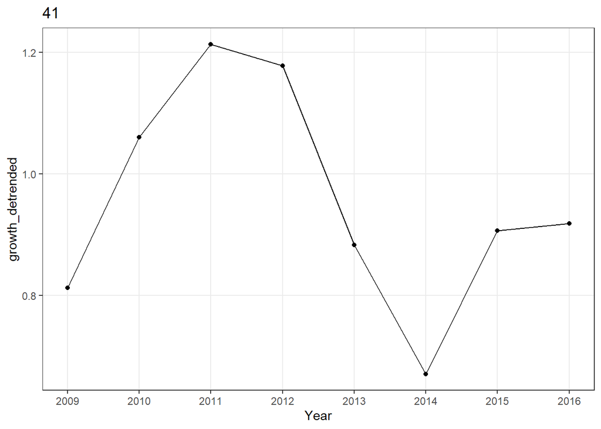

```r
ringplot(41)
```

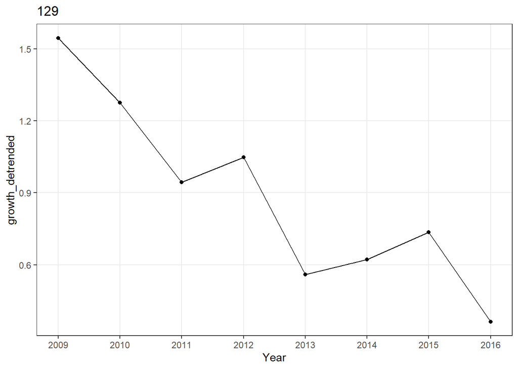

```r
add2017(41)
addsure(41)

ringplot(129)
```

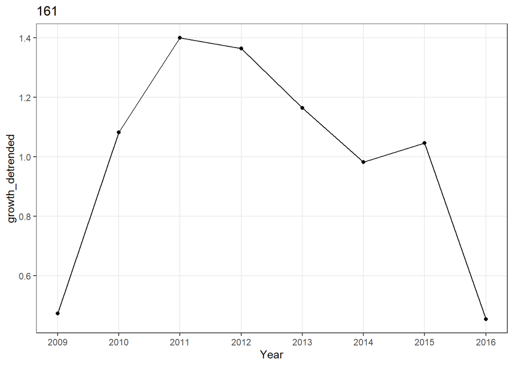

```r
addunkn(129)

ringplot(161)
```

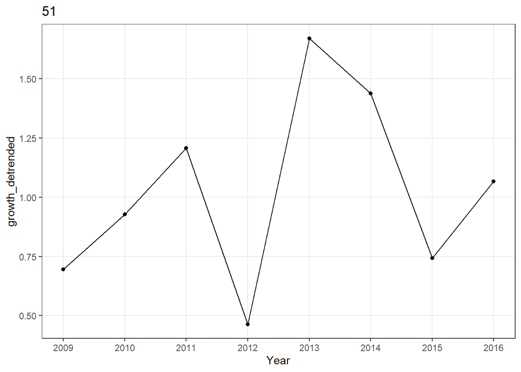

```r
add2017(161)
addsure(161)

ringplot(51)
```

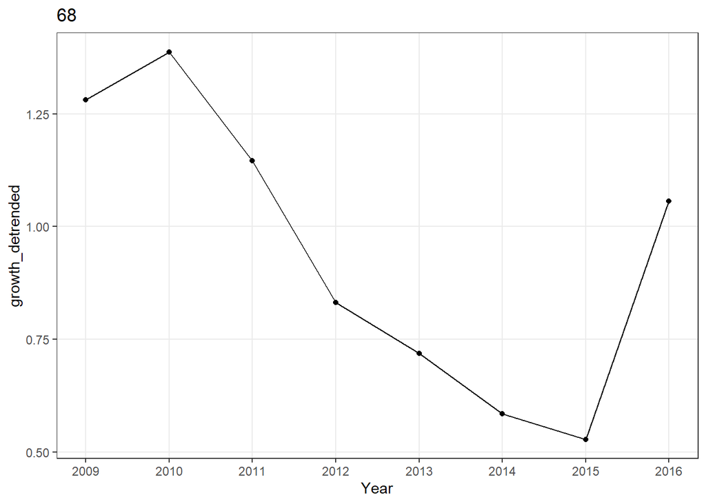

```r
add2017(51) # based largely on color and the fact that it looks like it actually is growing

ringplot(68)
```

```r
look(68)
```

```
##   tree HEIGHT PERC_NEEDLES  NEEDLE_COLOR   BARK   BUDS Growing
## 1   68     89           95 reddish brown intact intact     YES
```

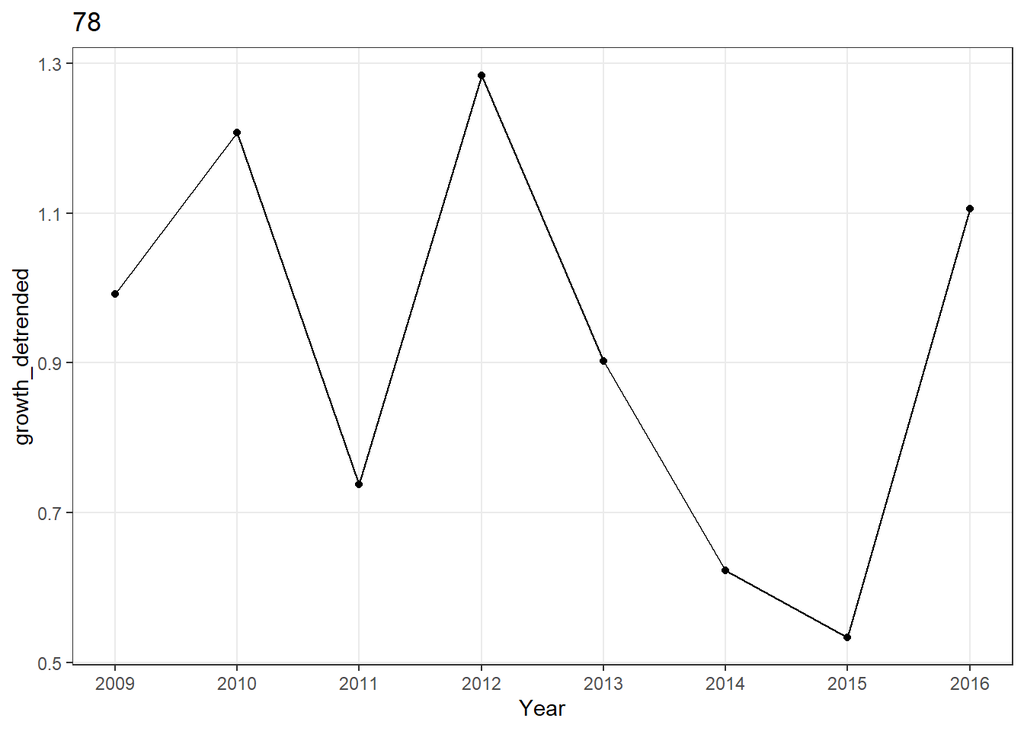

```r
add2016(68) # based largely on rings, the fact that it's red/brown

ringplot(78)
```

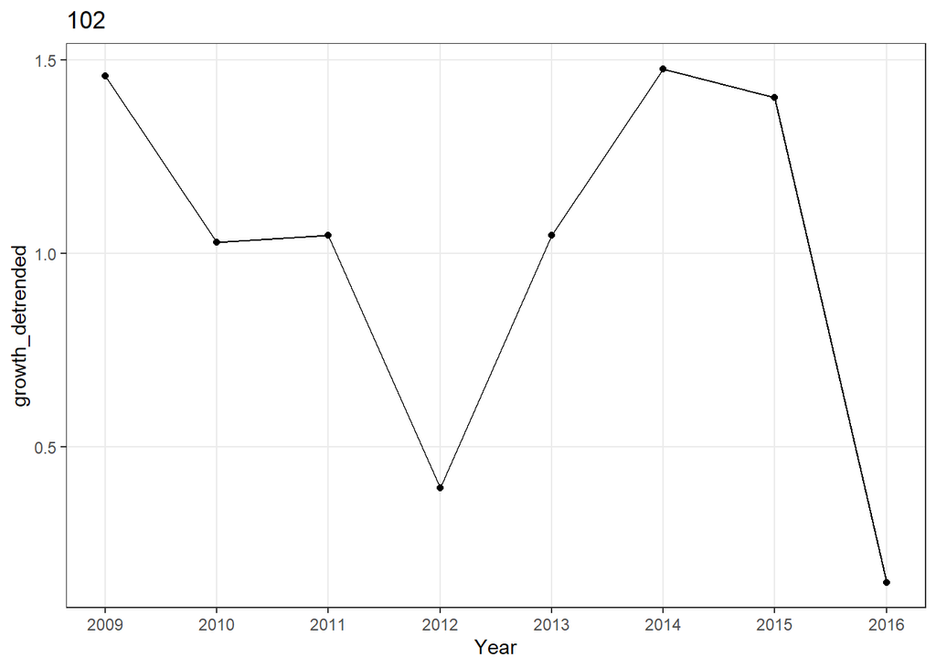

```r
add2016(78)
addsure(78)

ringplot(102)
```

```r
look(102)
```

```
##   tree HEIGHT PERC_NEEDLES NEEDLE_COLOR         BARK   BUDS Growing
## 1  102     28           90          red small cracks intact      NO
```

[figure not shown]

```r
add2016(102) # based largely on photo and ppt

ringplot(112)
```

```r
look(112)
```

```
## [1] tree         HEIGHT       PERC_NEEDLES NEEDLE_COLOR BARK
## [6] BUDS         Growing
## <0 rows> (or 0-length row.names)
```

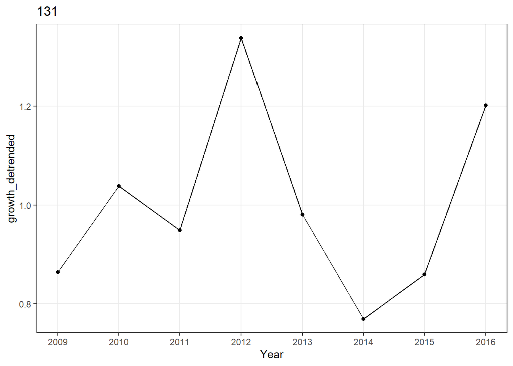

```r
add2017(112) # based largely on the fact that it's growing and looks so red in photo

ringplot(131)
```

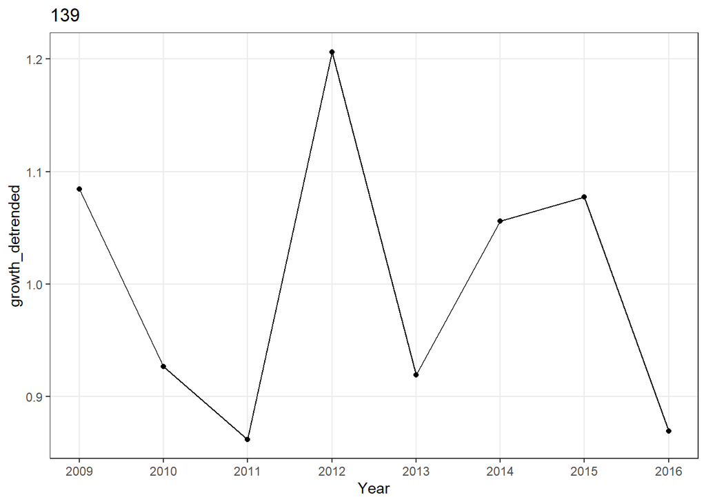

```r
add2016(131)
addsure(131)

ringplot(139)
```

```r
add2017(139) # Growing and looks like it may have hints of green
```

```r
rwla2_summary_unkn[11:20,]
```

```
## # A tibble: 10 x 2
##    tree      n
##    <chr> <int>
##  1 203       8
##  2 206       8
##  3 234       8
##  4 62        8
##  5 77        8
##  6 96        8
##  7 128       7
##  8 132       7
##  9 18        7
## 10 183-A     7
```

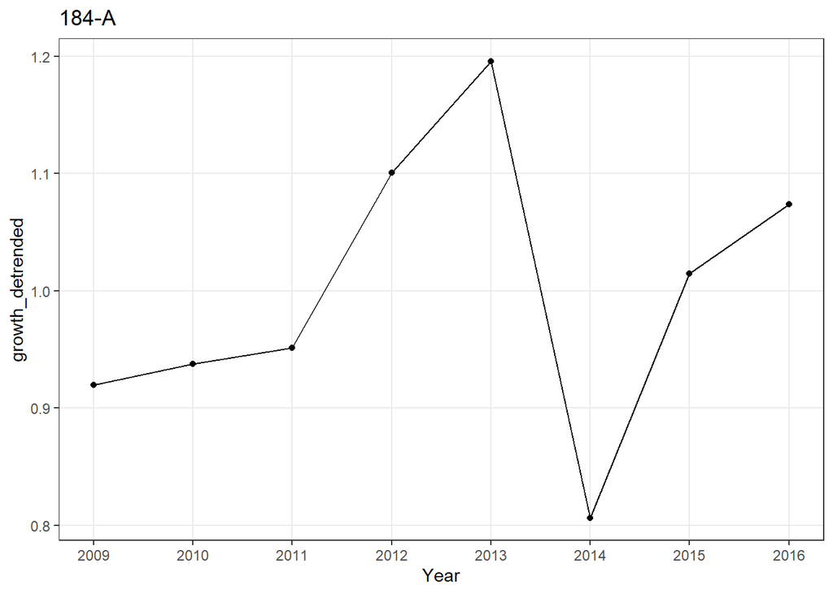

```r
add2016(4) # based on ppt

ringplot("184-A")
```

[figure not shown]

```r
add2016("184-A") # based on ppt

ringplot(195)
```